# Question 2

## (a)

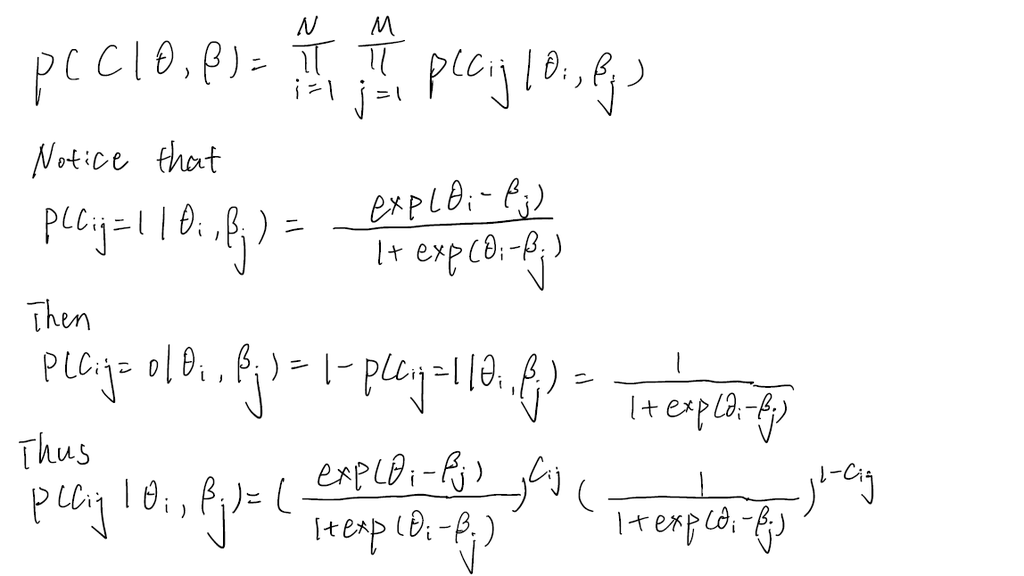

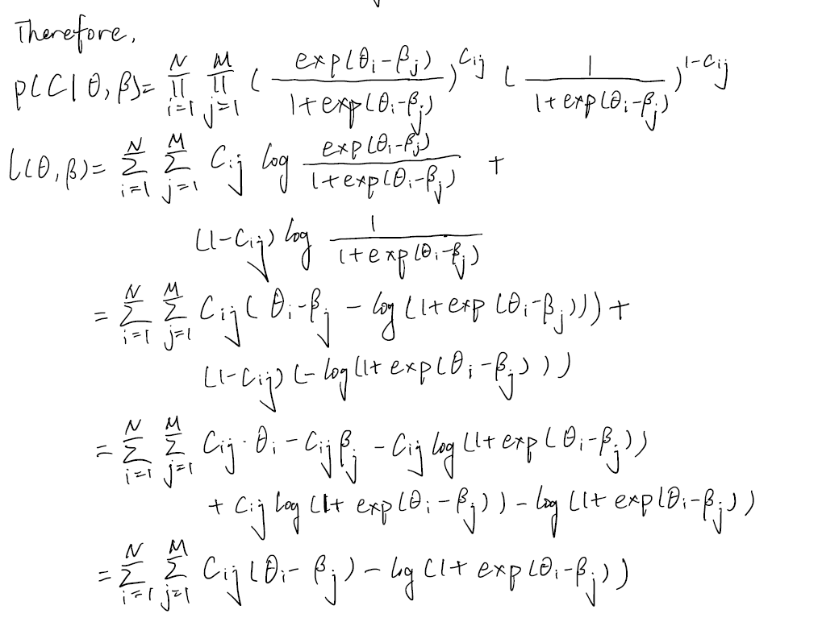

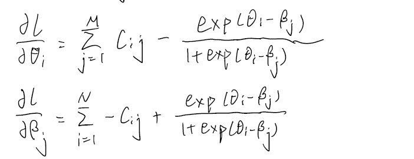

## (b)

In this part, I user the following hyperparameters:

**Number of Iterations:** 70

**Learning Rate:** 0.05

**Initialize theta:** All 0s

**Initialize beta:** All 0s

**Training process is shown as below:**

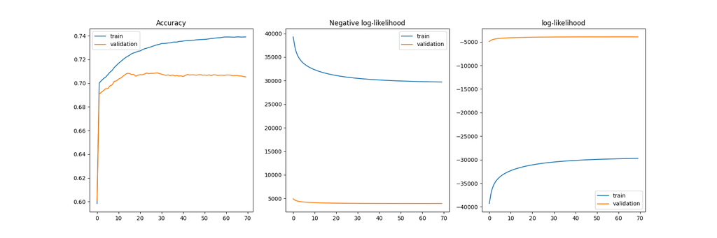

## (c)

**Final Train Accuracy is:** 0.7390100197572679

**Final Validation Accuracy is:** 0.7053344623200677

**Final Test Accuracy is:** 0.7047699689528648

## (d)

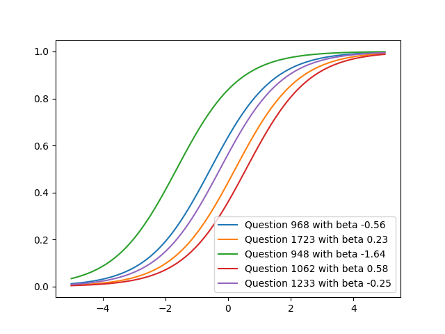

In this part, I use different as $p(c_{ij})$ as a function of $\theta$ given 5 different questions. We can see the shape of those 5 curves are in a shape of sigmoid function, which means it is a transformation of sigmoid function. The reason why it looks like sigmoid function is $p(c_{ij})=sigmoid(\theta_i-\beta_j)$.

We can consider $\theta$ as the ability of the students and the $\beta$ as the difficulty of the question. Then suppose we have the same value of $\theta$, that is we have the same value on x-axis, which means the students have same ability, the higher the value of y-axis is, the easier the question is. This is because the higher value of y-axis represents a higher probability that the students can answer the question correctly. From the graph above, we also can notice the curve of the question with lower $\beta$(easier) is at the top of this graph while the ones with larger $\beta$(harder) is at the bottom.